# Production and Operations Management - BA12A, Bataan Assignment

Jirah De Dios and Theresa Lopez

11/28/2017

# Authority of the Freeport Area of Bataan

This area is a government owned and controlled corporation. There are several companies that is situated in the area and it is located in Mariveles, Bataan. It is strategically locted between the Manila Bat and the South China Sea (FAB, 2015). The Freeport are provides several industries in different fields. One example is for manufacturing, they have a strong capability to host manufacturing industries producing a wide range of products with its infrastructure and trainable workpool. Another is for logistics, they are the only Freeport around Manila Bay area, which is considered as the country???s center of trade. It is also within the vicinity of two freeports in Region III which is located in Subic and Tarlac. FAB also has the potential for tapping other sources of renewable energy such as hydroelectric power, biomass and solar energy application. It currently hosts GN Power a 600-megawatt coal fired power facility that provides the cheapest power rate in the country. Another is for electronics, with its highly trained workforce, the FAB is capable of hosting electronics/semiconductor industries. Aside from the available technical professionals, the FAB also has links to training institutions to supply labor requirements. Shipbuilding and tourism, they are rich in natural resources as Mariveles possesses virgin forests, clean beaches, mountain ranges and flat lands suitable for ecotourism projects. For BPO/ IT services, they are ready for world class telecommunication network, BPO workplace facilities and trainable workpool, the FAB is set to be a business process outsourcing site in the country. (FAB, n.d.)

There are also five superior advantage when you invest or give your time to see the featured offerings of the Freeport Area of Bataan. These are Natural Endowments, Business Facilitation Supprot System, Superior Advantages, Facilities, Location and Incentives. For Superior Natural Endowments, there is a so called Natural Deep Harbor in which it has a depth of 11-13 meters, the FAB Harbor is ideal for national and international port operations as it can accommodate big cargo vessels. Also, human capital has a wide range of reach as it has the biggest TESDA manpower-training facility situated in the place and through this locators are assured of capable and well-equipped workers. For superior business facilitation support system, they have this IOSS, the Immigration One-Stop Shop wherein it provides fast and efficient immigration services to expatriate locators and their dependents. Also they E-Konek, it features elcetronic, paperless transaction of import/export permits from customs through the enhanced automated cargo transfer system. The Labor Center which takes charge of settling professional and labor relation disputes thus it interpreting employment contracts and monitoring work, hygiene and safety standards with the Freeport area. For the superior facilities, they have a dedicated power supply, providing the most affordable electricity cost in the Philippines. They are also the only industrial zone in the country that has its own dam and water treatment plant. Lastly, they are the only Freeport with an ideal transshipment hub, and strategically located at a prime transit point for domestic, regional and global shipping (Authority of the Freeport Area of Bataan, 2017)

# Guang Qiang Manufacturing Corporation

The first company that we have visited during our stay in Bataan is the Guangqiang Manufacturing Corporation. It is located in 7th Street Phase 1, Freeport Area of Bataan, Mariveles, Bataan. Its employers were all Chinese Citizens, the Financial Manager of the company is Ms Wanying Ye, the General Manager is Mr. Xincai Chen, and the Production Supervisor is Mr. Jianyong Wang. This company is basically a manufacturer of steel and produces moulds and fitted material as well as the other steel needed in manufacturing of branded bags and shoe factory. They also provide material supply like non-woven fabric, fiber paper, bonded leather, bontex, and lining fabric etc.

They are situated in the Freeport Area of Bataan as this become the center of trade, innovation and sustainable development in Asia. The place is an ideal transshipment hub, strategically located at a prime transit point for domestic, regional and global shipping. (FAB, 2015)

## Value Chain

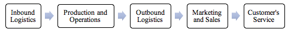

The first part of the value chain of the company is the inbound logistics. This is an important part of the operation of the business for a manufacturing firm. This part includes the processes of receiving raw materials, storing it in a warehouse as well as distributing it to different departments for the use of production. Technologies used in this process involves transportation, material handling, material storage, communications, testing and information systems. This process sets the stage for the succeeding steps in a business firm activities for a manufacturer. (Kokemuller, 2017)

The next part of the value chain is the production and operations part of the company. This involves the manufacturing of needed products to be performed as well as producing or transforming of raw materials into desired product. For this firm, the production used is by combining all the raw materials into one. The technologies used in this activity are process, materials, machine tools, material handling, packaging, maintenance, testing, buiding design and operations and information systems (NetMBA, 2010).

The third part of the value chain is the outbound logistics, this refers to the finished products going out of the business. This part of logistics relies on the transportation and storage of finished goods (Dowler, 2015). All the purchased finished goods are being transported to the customers. This process includes the sales section confirms the purchase order of the customer and then it will be sent to the warehouse for packing and picking the needed orders. Lastly it will be shipped to its client.

For the marketing and sales involves the identification of customer needs and the generation of sales. In this part, it includes the promotions, advertising of the company and getting of target customers. This process involves the inventory of sales and counting the breakeven or income of the company as well as checking if the company meets its target sales for the month.

The last part of the value chain process is the service. This includes all the activities required to keep the product or service working effectively for the buyer after it is sold and delivered. This process is important as it gives the customer of the company the satisfaction after they buy the product of the company.

## Processes

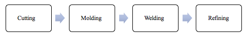

The process operation of the firm involves four departments. It includes cutting, molding, welding and refining. For cutting, the employee cut the steel with the desired measurement instructed by the supervisor. This department should cut the steel in an exact measurement so that it would be easy for the people from the next department to shape the steel into different forms. Next step is the molding part. This process involves forming the steel into different shapes depending on the desired formation that is requested by the higher management. They also form the frame of the bags. The third part is the welding, this process involves the joining of metals together. All the steels that were created by the previous departments will be put together in one material. The last process is the refining, this involves the final touch of the product. They clean, refine and remove excess parts that were not needed as well as they make changes that are necessary for the product to be more appropriate and for the improvement of the product.

## Equipment

Most of the processes for manufacturing their products were machine operated. Though machines do most of the work in producing their product, manpower is also significant to the firm as they are the ones who are operating the machines. The different equipment used by the company are metal cutter, slush cutting, welding machine, and tesla laser. The first equipment they use serves as the one that sharpens the steels. The metal cutter is use to cut the steels into their desired measurement. Before using this, they mark a measurement on the steel then the now uses the metal cutter. The slush cutter is use in the molding part of the steel. The use of this equipment to form the shape of the product they are doing. On the other hand, the welding machine is used on the welding process of the product. this is use to attach the metals and join it together. After all the process is done and is combined together, they use the equipment tesla laser. In this machine, it cut the detailed part of the metal and in this process it happens the lettering. This machine makes sure that the letters and design of the product are printed appropriately.

## Human Capital Requirements

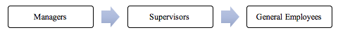

One of the important factors of a business to be successful is their employees. People of a company are the ones who does the work most of the time. The company???s human capital requirements depends on the job that is needed to be performed. They hire people through the (AFAB) Freeport Area of Bataan Websites and other job fairs. They get people near their area and have them interviewed as well as examined if they are qualified for the job. For the applicants to get the job they need to fill up an application form provided to them through the AFAB website or physically wherein their basic information is needed to be stated. Written in the form is the date you will apply for the job, full name stated in the applicant???s birth certificate, present address, age, highest educational attainment; whether the applicant is an elementary graduate, high school graduate, vocational graduate, college level, college graduate or post graduate and if the applicant has taken college, he/she will fill if what course does he/she took in college. Other needed information is their contact number, email address, desired position to the company, accomplished bio-data with picture and other requirements like the barangay clearance, police clearance, certificates, school or training credentials and NBI clearance. Once the applicant is called to report in the company, they first need to proceed to the labor center of AFAB and present their requirements. Pre-employment orientation is also provided by the Freeport Area of Bataan as well as the Job Induction Program.

The Guangqiang Manufacturing Corporation provides job opportunities to many Filipinos with different skills and knowledge. Job Positions they provide are Metal Mould Bender, this position would require female and of 18 years old above. A CNC/Lathe Machine Helper, this position can either be a female or male but should be 18 years old and above. For the CNC Machine Operator, this position should be operated by a male, 18 years old and above, with work experience of 1-2 years and a college graduate with any related course. An Auto CAD Operator should be male, 18 years old and above, with 1-2 years work experience on any position and should be a college graduate with knowledge or specialization on AutoCAD. For the Blade/Wire Cutting Operator, this position requires male, 18 years old and above and with 6 months to 1 year work experience in any company and with any position. For the company???s welder it requires male, 18 years old and above, a graduate of any vocational course and with at least 6 months to 1 year of relevant work experience. The company also has a translator of Chinese to English/Tagalog as its general manager and other high positioned people were mainly Chinese. This position requires male, 18 years old and above, at least on a college level with 1 ??? 2 years of relevant work experience and of course can speak/read/write in Chinese and English. Other positions provided by the company were Finishing Operator, it requires male and 18 years old and above. A Merchandiser for their products to be commercialized and for them to have several customers. This positon requires male, 18 years old and above, college graduate, and knows how to speak Chinese and English / Chinese and Tagalog. They also have an Electrician, it requires amle, 18 years old and above, a college graduate with a specific course of Electrical Engineer and with at least 1 to 2 years of relevant working experience. The Lathe Operator requires male, 18 yearsold and above, a college graduate with at least 6 months to 1 year of relevant working experience and must know how to operate lathe machines. A Laser Machine Operator and Wire Cutting Machine Operator requires male, 18 years old and above and with or without work experience. The Production Operator should be strong and physically qualified for the job, it requires male, 20 to 30 years old and at least college level. An Office Coordinator requires female, 20 to 35 years old, college graduate of any course and with at least 6 months work experience to other companies. (GUANGQIANG MANUFACTURING CORPORATION, , 2017)

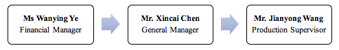

Heirarchy

The figure shown above are the stated names of the ones who has the highest position in the company. The general manager who is in charge of managing the whole facility, it is his job to make sure all is being well on the manufacturing place and the products that are being manufactured is in its good condition so that customers will be satisfied with what they offer. In Guangqiang, the general manager does all the talking. He knows every single detail of the company and being a Chinese citizen, he still manage to communicate well in English. He told us that he is also in charge of communicating to big companies that they supply. The financial manager on the other hand does all the financing of the business. She is responsible for the financial state of the company as well as developing strategies and plans for the financial goals of their organization. The production supervisor is in charge of giving information to the employees on how they will do on a certain job. this person ensure that the productivity of their employees is increasing from time to time.

# Medtecs Group of Companies

## Value Chain

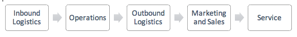

Medtecs is a company that produces fabrics and they create clothes, uniforms, etc. depending on the request of the customers to them. They produce different kinds of fabric to produce a specific product depending on the order given to them by their customers. The main product that they have to produce the material is thread which they bought in Taiwan.

Creating products needs a complicated process or procedure to achieve a perfect outcome. Medtecs have their own supplier for their raw material which is the threads to make the fabric. They check each and every roll of threads they ordered because once there is a defective part in it, the production can have a mistake and the product???s outcome will not be perfect and their customers may complain about the defective product that the company delivered.

The process of the business is that they will have orders from their customers. They export their products once or twice a month only and mostly, they supply their fabrics in Divisoria. After they receive the orders from their customers, they plan for the procedure and schedule when the production will start and the expected time in finishing the fabrics that was ordered to them.

After the first processes, they will make the fabrics and reach for the target time to finish the product. They will double check the products so that they will deliver the product in high quality and so that the customers will not complain about the product. After these processes, they will deliver the product to the location where the customer told them to deliver.

If ever they have defective products, they will put it aside and sell it to other customers who are in favor for the overruns of the factory. They will sell the product in a cheaper price so that there will be no waste. For the thread, if there is a defective product or thread, they will not put it into waste but rather, they will put it in pillows or are things.

Inbound logistics is where the raw materials are checked. The supplier of the company is from Taiwan. The workers will check first the products they ordered before they use it so that as much as possible there will be no overruns or delays in the production process.

In operations, this is where the process of making the fabric is in. This is also the process of checking the product if it reached the high- quality standard of the product to be delivered to their customers and packaging the fabrics and other products.

Outbound logistics is where the finished goods are in and also the dispatching and deliver of the product. The managers are the ones who prepare these things for the product to be delivered properly and orderly. They make schedules of every deliver that is needed to be done.

After delivery, the marketing and sales takes over. In this process, the business will classify on how to sell the products to the retailers and what strategy they should do in order to gain a lot of profit from the product. Advertising is also under in this process. It is in the strategy of the company on how they will deliver to the customers that their products exist and how their product help a lot of customers. This process will also give the customers idea to gain trust to the manufacturing company.

The last process is the service. This is about the warranty, maintenance and trainings. The factory should have these things for it to have a smooth flow of production and there will be no delay in delivery of the product as well as the production itself.

## Processes

In the first process where female workers do their part is the warping process. In this area, the yarns are gathered and the workers use one bobbin per yarn and it will be wound with each other from the reel spool. This process is one of the many complicated process in doing the fabric because firstly, it is very detailed. Each yarn should be sectioned properly by the workers. This is not a machine- work rather, it is done manually. The second reason is that this is one of the most important part in producing the fabric and it is very hard for the workers because they need to count the yarns then put it in to small holes.

Weaving is the second process in creating the fabrics. In this area, there are only few workers since the machine is working in this process. The worker will operate the machine in order for it to work. In the part centuries, weaving is done manually so the production of fabric is slow and there is only limited production but in the present world, weaving is done by machines so the production is fast and at the same time more fabrics are produced.

Weaving is the final stage in creating cloth or fabrics. After this stage, the fabrics will be put in the next department in which the cloth is cleaned, washed, dyed, organized and fold.

The fabrics are being checked by the machine if it is in a good outcome or not. After this, the dyeing process takes over. The color of the fabric always depends on the preference of the customer???s order to them. Once the fabrics are dyed already, the next process is spin drying. In this process, the excessive dye is also removed to make the color of the fabric equally distributed.

Scutchering is the next thing to do after the spin dry process. The fabrics are spread out to prepare the fabric for heating setting process. This is done by the machine and checked by the workers if it is processed properly so that in the next process, there will be no delays.

The next process is the stenter process. The fabrics are dried in this process and it is also heated by the machine to get the required width of the product to be delivered to the customers.  
By the heating process, the weight is also a factor in this process. In order for the fabric to be an excellent quality, there is a finishing touch of the fabric and also there is some application of special chemicals that they put to the fabric. This chemical helps in maintaining the color of the fabric at the same time remain its high quality.

The final process is the inspection. In this section, the fabrics are being double checked. They check the quality if they reached the requirements of the fabric that their customer gave them. the factors are being checked is the color shading on visual and data reading, correct width, weight, hand feeling and other quality that should be needed to achieve before delivering the product.

In the inspection process, there are three kinds which is the peaching, double folding and winding. In the peaching, the fabrics are in special process for sanding in making the fabric feeling smoother. This is done in selected products depending on the customer???s order to them. Another is the double folding. In this process, the fabrics are being fixed to packaging process in which the fabrics are for double fold. Lastly is the winding process. It is also the packaging process in which the fabrics are done in long folds.

## Equipment

In order to create the finished product which is the fabrics and the linens, they have different kinds of machines to produce the product. Machines is one of the big factors or material that is needed to create the finished goods. The manufacturing company use different kinds of machines that can help the production made easier and faster. Unlike other factories, in the first stage, there is a need of a person to insert every thread in the loop. The other steps are done by the machine and manned by the factory workers. Before operating the machines, the workers had their proper training in operating the machines and how to deal with it if ever the machine is not functioning properly. The area where the fabrics are being dyed, cleaned and finished, there are only few workers in the area because the fabrics are being done by the machine and there is no need for more workers to do it. Those few workers just operate the machines and check if it is working properly and accordingly.

In every process or procedure of creating the product, it is observed that there are fewer of workers in every stage. The most complicated once have a lot of factory workers which are the first parts of the process while the non-complicated once which are operated by the machines have a few factory workers. In the first stages of creating the product, there are a lot of female factory workers but as the process goes, there are fewer female workers until in the dyeing process in which there are no female factory workers. In the dyeing process, there is a need to have more force to do the work so in that area, all the workers are men.

Machines can be defective in the middle of the production process. This can lead to the delay of productions in the factory. In order for the process of creating the fabric smooth, the factory workers, the supervisor and other workers check the machine from time to time.

## Human Capital Requirements

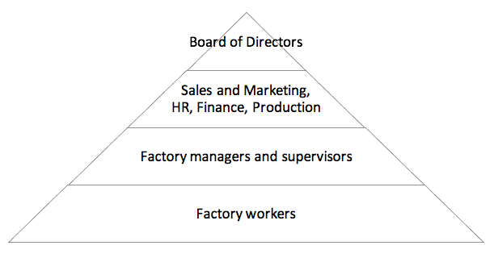

Hierarchy

In factories, there is a need to have a lot of workers especially that creating a product needs a lot of hands, meaning, workers should have skills, patience and perseverance towards work.

The manufacturing company hire workers by recruiting them. Most of the workers lived in Bataan. They are being interviewed and do some process to be hired to the work. The qualifications to be hired in this kind of industry are the future workers should be determined, patient, knows the kind of work they applied, they should be healthy and responsible in everything they do. After being hired, the company give them trainings and background about the company that the future workers are in. since the workers are working in a factory, they should have benefits especially that they are in an unsafe zone. In the Philippines, the workers should have benefits like Pag-ibig, Social Security System and PhilHealth. These three benefits require the company by the government to provide the employees especially that factories, including MedTec is a very dangerous zone for the workers. The operation of factory is 24 hours from Monday to Saturday and on Sunday, it is the workers??? day off. There are three shifts in the factory since the required time of the workers to be in the factory is eight hours.

There are three supervisors who are responsible in giving instructions and orders to the worker to make the process of the production smooth and organized. They are the ones who knows all the process of the production and have a lot of knowledge on how the business works rather than the other workers or employees.

The company is open for hiring. As of the moment, they need a marketing assistant. The requirements that they need in order to be accepted to the job is the future worker can be male of female who is 18 years old and above that is a college graduate and has one to two years of job or work experience.

Aside from the qualification, the company is specific in terms of duties and functions. The duties that the hired employee will do is to prepare the reports, brochures and documents of the company. Another duty is to organize and host presentations of the company as well as it is their duty to visit their customers. They are also required to assist in the company???s promotional activities and help in organizing market research.

The company don???t produce threads rather, they order the raw materials from other country and they will process it to produce the finished product which is the fabric. The thread is exported from Taiwan to the Philippines.

# FCF Manufacturing Corporation

FCF Manufacturing Corporation located in 11th Avenue, Freeport Area of Bataan, Mariveles, Bataan. They are basically engaged in the business of manufacturing of high quality fashion bags, leather bags and other leather goods specifically the brand Coach primarily for Export in USA, Europe, Asia and other parts of the globe.

## Value Chain

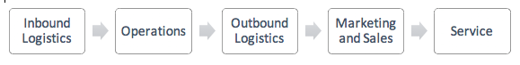

Value Chain

The first part in the value chain is the inbound logistics. In this process, the raw materials are inspected by the workers. They inspect the quality of the raw materials at the same time if the ordered products are right and the quantity is correct based also on the order they said to their suppliers. The inventory flow is done also mostly by the managers and supervisors since they are the ones who knows well on how the production is done. In this part of the process the supply schedules are also determined.

The operation is the next process. In this part the flexibility of the floor plan, operating concepts, sales tracking system, etc. are determined. The floor plan of the factory is determined by different departments. They section every process so that the production process will be organized and that the sending of every product to each department will be smooth. The corporation???s supply line is cutting the leather, skiving, lamination, die cutting using the machine, inking, putting the cut products together, checking and lastly is the packaging.

Cutting is the first step in which the leather is cut in to smaller pieces so that it is easier to use. The next process is the skiving. In this process, the leather is being cut or skived. This process is made to make the sides of the leather thinner and easier to sew. If the leather in the edge is very thick, the outcome of the product which is the bags or the wallets will not be excellent and high quality as expected by the customers who will buy the products that they produce.

Lamination is the next process. The product leather is being laminated so that the leather will be shiny and not easily broken. The leather is protected by doing this process. Die cutting the leather is the next things that a worker should using a machine. The worker???s part in this process is to maximize the leather so that there will be limited wasted leathers. The leather is very expensive so it should be maximized properly.

Inking is the most interesting part in the process. The sides or the edges of the leather is inked manually by the worker so that the outcome will be clean and organized. The next process of the operation is to assemble it and sew it manually to create a product such as wallet, pouches and bags.

The product is determined if it is rejected or not in the checking process. In this part, the products are checked one by one manually. Coach wants to remain a high-quality product because it is known for its near perfection products. In order to maintain the reputation that they have, they check each and every product that they produce. After checking properly, the products, are put in to the next department which is the packaging section. If the product did not pass the quality standard, the company will destroy the product. They do this because they want to just deliver to the customer perfect products and they don???t sell overruns to remain the reputation of the company at the same time the position of the company to the minds of the people. Again, the products are packaged one by one through manual process. They carefully put the products in the box so that the formation of the product is perfect and still in high quality.

Outbound logistics is done after the production process. In this part, after the packaging, the products are delivered to its warehouse where the products are ready for shipment and delivery to its customers. Other countries order the products and it is the responsibility of the business to deliver or ship it internationally. When the orders are taken from the customers, they will dispatch the product and bring it to its customers. The span of time that the product is in the warehouse is only three months. After three months, if the products are not delivered or ordered by the customers, the company will destroy them.

The next in the value chain is the marketing and sales. In this part, advertising of the product, pricing, sales analysis and other factors that can affect the marketing and sales are in this process. The distributors to the retailers do their part in this process. They will advertise the product to the people so that people will know that they have a new collection that can be bought in Coach stores.

Lastly is the service in which this is about the warranty, maintenance, trainings, upgrades, etc. In this part, the warranty is about the product when it is already purchased by the customer that will use the product. Coach gives warranty to assure the customers that their product is in high quality and they only give what is best for their customers. The corporation also gives trainings to its employees on how to handle customers, they give the background of the company as well as the product that they are selling. The company doesn???t want to maintain what they have in the present, rather, they want to improve in the future to serve their customers well. They plan for upgrades of the product and make designs that surely the customers will buy.

## Processes

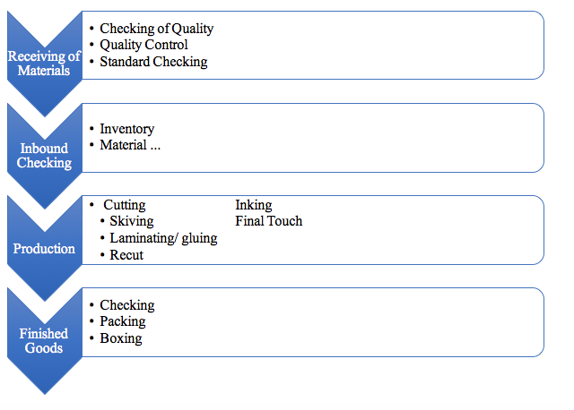

Process

The process that this company incur is just like any other regular companies. Since they supplying international companies, they follow a certain strict process with regards of their production and manufacturing their goods. The first process is the receiving of materials. All the materials that are coming in their warehouse or manufacturing place were being checked and have it in an inventory so that they can control the number of materials. Also, once they have all the new raw materials in them, each one of it are being checked whether it has defects or if there is something wrong with the material that will used in their products. They have this so called ???Coach Standard??? wherein each and every raw materials as well as the finished products needs to pass the standard of the brand is providing. The company have this certain warehouse wherein they store all their raw materials before transferring it in the production area.

The next process in producing Coach Handbags would be the inbound checking. Every material also have standards when it comes to maintaining its quality when storing. One example is the main material that they using for their products which is the leathers. When we went to their warehouse, they have a separate storage for their leathers and it is air-conditioned. According to their General Manager, to preserve a certain leather, it needs to have 65 degrees below temperature so that it maintains it appearance as well as to have better look.

The third part of the process is the production or the manufacturing of the product. There are several processes under it which are cutting; in this process, the employees cut the fabrics and leather into its designated shape and form it as a handbag. Next process is skiving; in this process they cut the fabrics and leathers into thin layers and pieces. Laminating and gluing is the next process in the production wherein the fabric is doubled so that it will have more quality in the next processes. It is also glued and process it in a machine to spread. The next process is recutting; they recut the fabric and leathers to its designated final forms and then it will be inked in its desired color. The last step in production is the final touch wherein it refine all the small defects on the product. They will have a final look on the manufactured product so that it will reach the Coach standard.

The last thing in the process part of the product is the processing of the finished goods. After manufacturing of production the production department, it will now be forwarded to the finished goods department wherein they will check, pack and box the products. In checking, they will check small detailed defects on the product and it is the employees??? responsibility to check whether they will accept it and forward it in the packing part. The packing part is where they will cover the finished products. The last part of process in the finished goods processing is the boxing part wherein each orders of their customers will be assigned to different boxes and will be shipped to its designated places.

There is a separate process for the moulded patterns. These are the ones who identify the bags whether it is original or not.

## Equipment

Machines is one of the main equipment that the corporation needs in order to produce bags, wallets and pouches. The factory has different kinds of machines used for production like the cutter. This helps the cutting process easier and accurate. Another is the gluing machine wherein the machine will be the ones who will put glue in the leather and the worker will be the ones who will put the two leathers together. There is also and inking machine which the function its function is to put the ink in the edges of the leather. This machine should be maned because the leather should be put one by one and removed one by one as well. There are also other kinds of machines the company use for the production.

Machines can be defective unexpectedly. The company handle this problem by providing extra machines so that the manufacturing process to reach the quota will not be destroyed since time is very important in the factory. The workers are also trained on how to deal with equipment that are defective.

## Human Capital Requirements

FCF Manufacturing Corporation provides job opportunities in more wide scale process. They have employees from different parts of the Philippines unlike the other companies in FAB they only got their employees around Bataan and its nearby provinces. They provide jobs for different kinds of skilled people with regards to age and educational attainment. Some of the job positions they provide is an Impex Staff. For this position, it requires either a male or a female, 18 years old and above, a college degree holder, has a knowledge in Microsoft office and a fast learner. An IQC requires a male or female, 18 years old and above, a college level, and has an experience is an advantage. For tableworks staff, it needs a female and should be 18 years old and above. A warehouse manager should be a male or female, 18 years old and above, a college degree holder with 6 months to 1 year work experience. An Industrial engineer requires male or a female, 18 years old and above and a college degree holder specifically an Industrial Engineering. A pattern maker, it requires either a male or a female and should be 18 years old and above. For an Executive Assistant, this position requires female, should be 18 years old and above and a college degree holder. A junior merchandiser can either be a male or a female, 18 years old and above and should be a college degree holder. This position???s responsibility is to assist all merchandising work and to perform other jobs that may be assigned from time to time. A senior merchandiser???s responsibility is same with the duties of an junior merchandiser but this position requires either a male or a female, 18 years old and above and a college degree holder. A sewer and a trainee sewer requires male or a female, 18 years old and above with 6 months to 1 year work experience. An electrician should be male, 18 years old and above and must possess TESDA license or certification. This positon???s duties is to know the basic knowledge in electrical circuits, knowledgeable in forward and reverse control, temperature control, power supply AC and DC, pneumatic and hydraulic control as well as knowledge in Programmable Logoc Control. A logistic manager can either be a male or a female, knows how to manage logistic operation in order to ensure timely and cost effective delivery and arrival of cargo, coordinate reports and documentation based on logistic movements and distribute them according to requirements, needs to ensure adequate logistic preparedness through contingency planning and continue preparedness reviews, knows how to ensure that accurate and complete accounting reports and internal control system are functioning and that all relevant records are maintained, to perform other duties as assigned by general manager/production manager, to supervise staff as required, coordinate with trucker, broker, and forwarders, to track movement of shipment both export and import, to keep and maintain files, to provide monthly report if needed and requested, to communicate directly to buyers logistic officer, forwarder, broker, and other government authorities, needs to schedule weekly shipping plans, he is also responsible in all documentation for export and import matters such as processing in PEZA, AFAB, Customs, EAD and GTEB, prepare and update order balance, prepare monthly sale and purchase report, prepare report for DTI, to check quotations, billing, and other related expenses of export/import matters and signatory of all export and import documents. Other positions that the company provides are cutting operators, high head machine operator, quality controller, table works and skilled sewer.

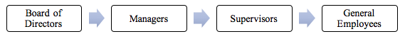

The board of directors??? is one of the highest in the hierarchy of every company, their responsibilities is to guide the company for the betterment and govern the policies so that the employees would know on how to manage themselves into the company. The managers on the other hand, are the ones who manage the facility. It is his job to make sure that customers are satisfied with the companies??? manufactured products as well as managing every in and out materials in the company. The supervisor is the one who supervise the employees to do their jobs. He/she is the one who does the talking to the employees and communicates to the managers for a better understanding between the two parties.

# Bibliography

Department of Labor and Employment. (n.d.). DOLE. Retrieved from NOTICE OF FILING OF APPLICATION/S FOR ALIEN EMPLOYMENT PERMIT/S (AEP/s): http://ro3.dole.gov.ph/fndr/mis/files/08-10-15.pdf

GUANGQIANG MANUFACTURING CORPORATION, . (2017, November 15). Job Opportunities. Retrieved from AFAB: http://www.afablabor.com/job-opportunities/category/guangqiang-manufacturing-corporation

Kokemuller, N. (2017). Chron. Retrieved from What Is Inbound Logistics & Manufacturing?: http://smallbusiness.chron.com/inbound-logistics-manufacturing-14398.html

FAB. (2015). Retrieved from Authority of the Freeport Area of Bataan: http://afab.gov.ph/?page_id=48

MSG Team. (2016). Management Study Guide. Retrieved from Understanding Production and Operations Management: http://www.managementstudyguide.com/production-and-operations-management.htm

Dowler, J. (2015, May 26). Paragon FIlms. Retrieved from What is Outbound Logistics?: http://www.paragon-u.com/what-is-outbound-logistics

NetMBA. (2010). NetMBA Business Knowledge Center. Retrieved from The Value Chain: http://www.netmba.com/strategy/value-chain/

FAB. (n.d.). GovPH. Retrieved from Authority of the freeport area of bataan: http://afab.gov.ph/?page_id=47

Porter’s Value Chain Understanding How Value Is Created Within Organizations. (n.d.). Retrieved from Mind Tools: https://www.mindtools.com/pages/article/newSTR_66.htm

Porter’s Value Chain Understanding How Value Is Created Within Organizations. (n.d.). (M. Tools, Producer) Retrieved from https://www.mindtools.com/pages/article/newSTR_66.htm

Bellis, M. (2017, April 8). The History of Textile Production: Making Fabric. Retrieved from https://www.thoughtco.com/history-of-textile-production-1991659

Fabrics. (n.d.). Retrieved from Tenline: http://www.teonline.com/knowledge-centre/fabrics.html

Labor Code of the Philippines. (n.d.). Retrieved from http://hrlibrary.umn.edu/research/Philippines/PD%20442%20-%20Labor%20Code%20of%20the%20Philippines.pdf

Tram. (2016, May 14). Note on Business Model Analysis for the Entrepreneur. Retrieved from scribd: https://www.scribd.com/document/312576774/Note-on-Business-Model-Analysis-for-the-Entrepreneur

Job opportunities. (2017, October 5). Retrieved from http://www.afablabor.com/job-opportunities/category/medtecs-group-of-companies

Rappler. (2012, May 27). Rappler. Retrieved from Made in the Philippines: more Coach bags: https://www.rappler.com/business/6018-made-in-the-philippines-more-coach-bags

Isip, I. (2014, January 13). Malaya Business Insight. Retrieved from Luxury bag suppliers find biz good in PH: http://www.malaya.com.ph/business-news/business/luxury-bag-suppliers-find-biz-good-ph

Custodio , D. (n.d.). Authority of the Freeport Area of Bataan. Retrieved from http://investphilippines.gov.ph/incentives/authority-of-the-freeport-area-of-bataan/

Challa, L. (n.d.). Impact Of Textiles And Clothing Industry On Environment: Approach Towards Eco-Friendly Textiles . Retrieved from http://www.fibre2fashion.com/industry-article/1709/impact-of-textiles-and-clothing-industry-on-environment?page=2

Price, J. (2016, May 23). 2016 State Of The U.S. Textile Industry. Retrieved from http://www.textileworld.com/textile-world/features/2016/05/2016-state-of-the-u-s-textile-industry/

Manufacturing Industry. (2010, June 29). Retrieved from http://www.economywatch.com/world-industries/manufacturing/?page=full

Made in the Philippines: more Coach bags. (2012, May 7). Retrieved from https://www.rappler.com/business/6018-made-in-the-philippines-more-coach-bags